# [HDFS 276](https://www.andrewdismukes.com/hdfs276)

# Navigational Notes

# Slides are presented as **2D webpages**. You can navigate up, down, forward and back. **Advance forward for Topic Headings**. **Advance down for Topic Content.**

# Let’s Practice!

# This is A Topic Heading

## **You got to the Content!**

# Did you see the content? If not, go back one slide and click down!

# Well Done!

# Further Notes:

## Remember: Slides are presented as **2D webpages**. **Advance right for topics**. **Advance down for details.**

## Further options:

- Press ‘O’ for a slide overview. This is very useful!
- Press ‘F’ for fullscreen.

Make sure you look at all slides. If a down arrow is present that means there is more information below. Advance forward when the down arow become unavailable or when you want to skip to a certain section.

# Ok, lets get started!

# Welcome to [HDFS 276](https://www.andrewdismukes.com/hdfs276).

## This is your syllabus. Your lectures will have a similar format.

## I’m Andrew, and I’ll be your instructor this semester.

## Office hours and contact information:

Please get in touch with me with any questions or concerns you may have.

`Email:` dismukes@iastate.edu  
`Office Hours:` By Appointment

## Make sure to watch the introduction video!

[Vimeo link](https://vimeo.com/222006841/38f5ec4011)

# Goals

## The goal of this class is for you to learn. Because this is an online class, we will do more independent review than you would normally do in an in-person class.

## This is not busywork!

You have more freedom to learn the material when you choose, but you must treat this class with the same respect for time requirements that you would an in-person class. Excercises are **SPECIFICALLY** designed to focus and amplify core material and address common questions. Normally you would spend 2.5 hours a week in-class, and an additional 3-5 hours a week reviewing material outside of class; that level of commitment is what I expect as well. It is necessary to learn this content.

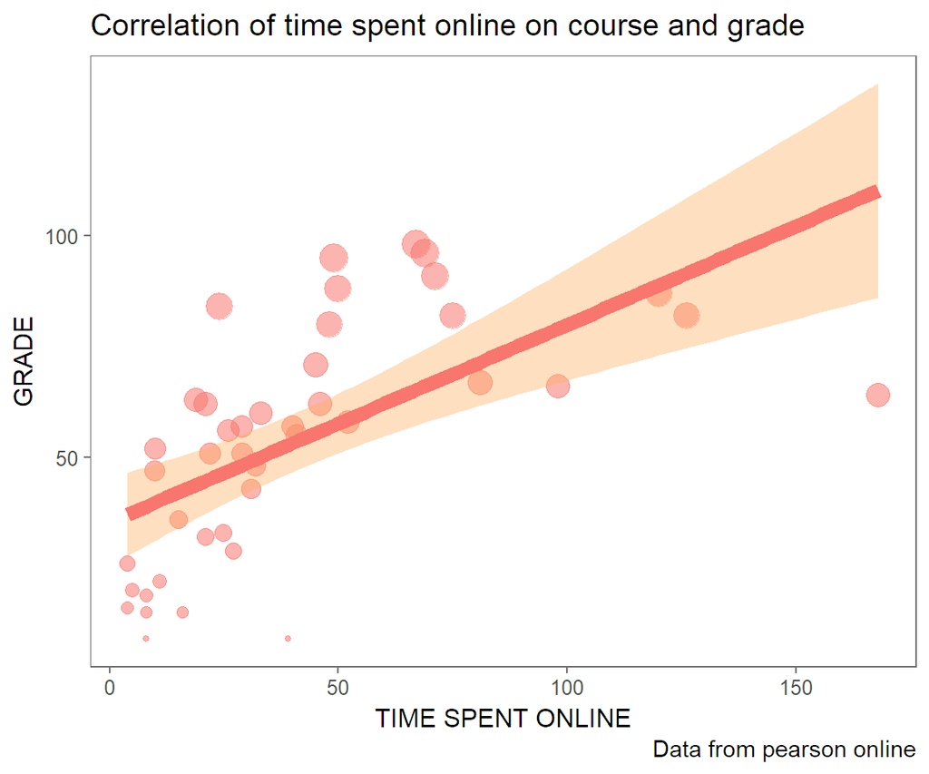

**On Average, the more time you spend with the material, the better your grade!**

# Course Description

## We will cover:

- behavioral, biological, and psychological aspects of human sexuality;
- the role of sexuality in human development;
- critical analysis of media and research;
- communication and decision-making skills relating to sexuality issues and relationships.

## Textbook

Hock, R. R. (2016). Human sexuality, (4th Ed.). Boston, MA: Pearson.  
**Make sure that you use the 4th edition of the textbook.**

[figure not shown]

# Policies, Cheating, Harassment, & Special Accomodations

## Academic Integrity and Misconduct

High standards of academic honesty are expected in this course. Students are expected to complete their own work. The “ISU Academic Dishonesty Policy” is strictly enforced in this class. This policy may be found at: http://www.dso.iastate.edu/ja/academic/misconduct.html. Any form of cheating, plagiarism, or academic misconduct will result in referral to appropriate university personnel. Academic misconduct includes, but is not limited to, using work you submitted for another class without proper citations, using others’ work, and writing ideas, facts or opinions that are not your own, without citing the appropriate source. Other examples include: copying another student’s work; collaborating or sharing information with another student for completing tests or homework when not authorized to do so by the instructor; purchasing a paper from another student and submitting the work as your own; selling your work to another student; or having another student complete your work, quiz, in-class activity, or test.

## Harassment and Discrimination

Iowa State University strives to maintain our campus as a place of work and study for faculty, staff, and students that is free of all forms of prohibited discrimination and harassment based upon race, ethnicity, sex (including sexual assault), pregnancy, color, religion, national origin, physical or mental disability, age, marital status, sexual orientation, gender identity, genetic information, or status as a U.S. veteran. Any student who has concerns about such behavior should contact his/her instructor, Student Assistance at 515-294-1020, or email dso-sas@iastate.edu, or contact the Office of Equal Opportunity and Compliance at 515-294-7612.

## Special Accommodations

Iowa State University complies with the Americans with Disabilities Act and Sect 504 of the Rehabilitation Act. If you have a disability and anticipate needing accommodations in this course, please contact the course instructor to set up a meeting within the first two weeks of the semester or as soon as you become aware of your need. Before meeting with the instructor, you will need to obtain a SAAR form with recommendations for accommodations from the Disability Resources Office, located in Room 1076 on the main floor of the Student Services Building. Their telephone number is 515-294-7220 or email disabilityresources@iastate.edu. Retroactive requests for accommodations will not be honored.

## Religious Accommodation

If an academic or work requirement conflicts with your religious practices and/or observances, you may request reasonable accommodations. Your request must be in writing, and your instructor or supervisor will review the request. You or your instructor may also seek assistance from the Dean of Students Office or the Office of Equal Opportunity and Compliance.

## Dead Week Policy

This class follows the Iowa State University Dead Week policy as noted in section 10.6.4 of the Faculty Handbook: http://www.provost.iastate.edu/resources/faculty-handbook.

# Structure

## Each week you will:

- Submit questions for the following week.
- Answer questions from the current week.
- Summarize the past week.